# A3: SPL Library Checkouts

### Introduction

This dataset informs us on book checkouts in the Seattle Public Library from 2013 up to 2022. It gives information on types of books, types of checkouts, authors, dates, publishers, etc. I chose to analyze the trends of physical book checkouts vs digital books over the years, the type of checkout someone did (magazines, music, movie, etc.) and the authors with the most books checked out. I did this because I am really interested in how the pandemic affected book checkouts and what kind of books people are interested in/checking out. I also chose to find the top authors because I am interested to know if I am familiar with any of them or their works, and I also wanted to see what people are reading the most.

### Summary Information

While analyzing the data, I found a few interesting values that reflect the trends I noticed. The first trend I found was confirmed by my first chart. The amount of Physical books being checked out has dramatically decreased between 2013 and 2022. In 2013, physical books made up 93.1823386 of all the books being checked out. However, in 2022 they only made up 39.7759707 of all books checked out. Considering the pandemic which didn’t allow people to leave their house as much as usual, this number makes sense. Another trend that aligns with this fact is the amount of ebooks checked out in recent years. The date with the highest amount of ebook checkouts is 2022-9-01, unsurprisingly this date is in 2022. 2013-1-01 is the date with the least amount of ebook checkouts, which is in 2013. This follows previous trends we have seen, since the popularity of digital books has increased over the past ten years. My favorite author, Kate DiCamillo, has a few books featured in the dataset, however her most popular book is Mercy Watson to the Rescue, with a high of 132 checkouts in a single month.

### The Dataset

This data was provided by the Seattle Public Library, and was published onto the Seattle Open Data Portal. It is frequently updated, with the latest update being on February 6, 2023. The parameters of this data include usage class(physical or digital), the checkout type(music, movies, books, etc), the material type (ebook, audiobook, etc), the year and month the item was checked out, how many items were checked out, the title of the item, the ISBN, the subject, the publisher, and the year of publication. The data was collected by putting together data from the various online checkout sources (Freegal, Horizon, Overdrive, etc.) and also includes data from historical sources. The data was collected to keep a good record of checkouts from the Seattle Public Library. Some ethical questions we may need to consider when working with this data is what locations the data is coming from, meaning are there any locations that are being blacklisted or do any locations have limited supply when compared to other library locations. Possible limitations with this data could be that the exact date of checkout isn’t given, only the month and the year. Another big limitation is the location that the item was checked out from isn’t included. A problem that the data has is that some titles or creator names are not included, so they cannot be properly analyzed.

### Physcial VS Digital Book Checkouts

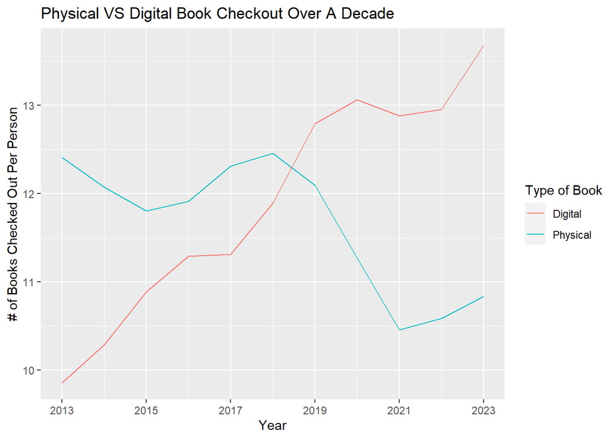

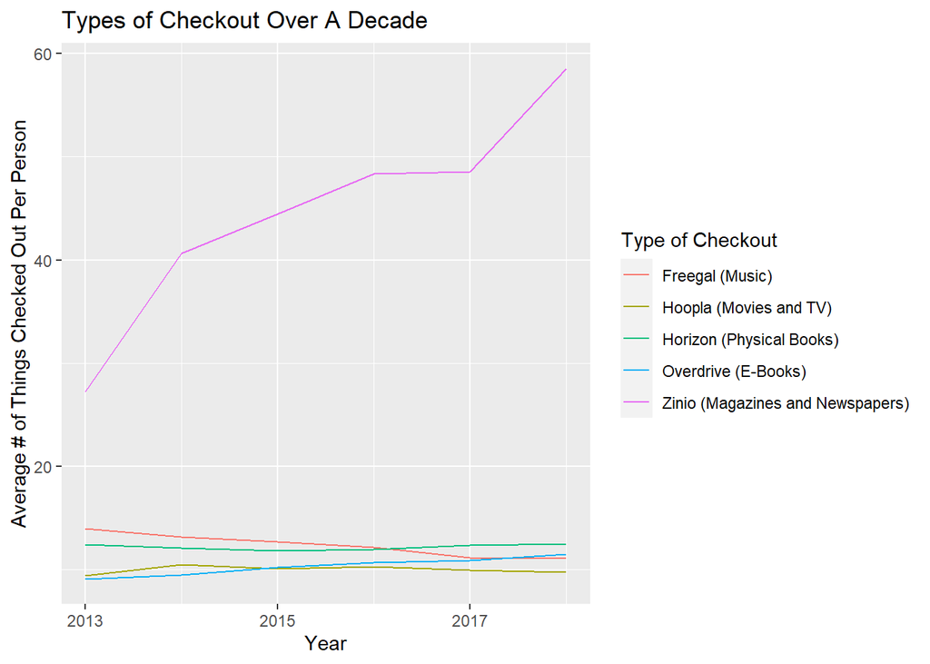

### Top Authors by Number of Checkouts

For the last chart, I wanted to look at what authors are the most popular and I measured that by looking at their overall checkouts. I specifically wanted to know about authors, not the publishing company, and I wanted to make sure the author was a single person and had their name updated in the data set that I used. I wanted to know if I was familiar with any of the most popular authors among Seattles Public Libraries. I found that the most popular author was Mo Willems, the author of many well known childrens books. The next most famous author is Jim Davis, who is the creator of Garfield. I found an interesting trend among the top 5 authors. They were all children’s books authors, which may give a huge clue as to who is checking out the most books from Seattle Public Libraries.

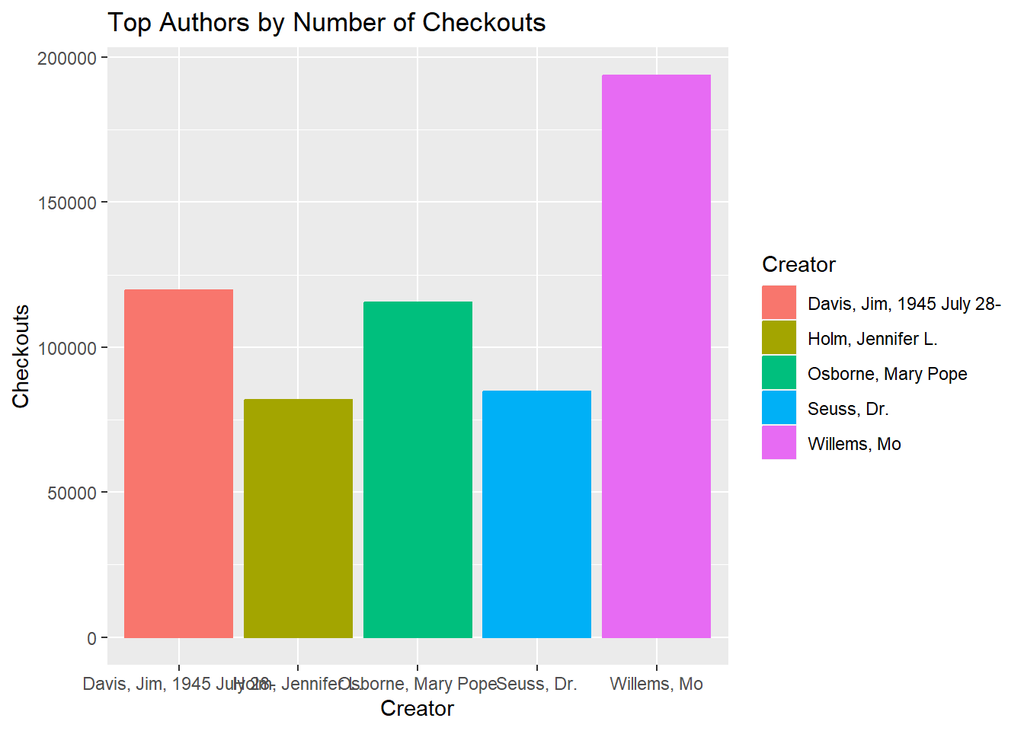